# Projeto_NBA

Thomas Raphael Zonta

2025-04-08

# Abrindo bibliotecas

```r
library(readxl)
library(tidyverse)
library(ggplot2)
library(dlookr)
library(dplyr)
library(purrr)
library(knitr)
library(summarytools)
library(GGally)
library(ggpubr)
library(mice)
library(corrplot)
```

# Importando base dos jogos

```r
jogos_2024 <- read_excel("C:/Users/Pichau/Documents/RSTUDIO/NBA/jogos_2024.xlsx")
jogadores_2024 <- read_excel("C:/Users/Pichau/Documents/RSTUDIO/NBA/jogadores_2024.xlsx")
```

# Checando cabeçalho base jogos

Para poder visualizar quais dados nós temos para trabalhar usamos o comando head() para visualizar o topo do dataset.

```r
head(jogos_2024)
```

| Round Number | Date | Location | Home Team | Away Team | Result |
| --- | --- | --- | --- | --- | --- |
| 1 | 2024-10-22 23:30:00 | TD Garden | Boston Celtics | New York Knicks | 132 - 109 |
| 1 | 2024-10-23 02:00:00 | Crypto.com Arena | Los Angeles Lakers | Minnesota Timberwolves | 110 - 103 |
| 1 | 2024-10-23 23:00:00 | Little Caesars Arena | Detroit Pistons | Indiana Pacers | 109 - 115 |
| 1 | 2024-10-23 23:30:00 | State Farm Arena | Atlanta Hawks | Brooklyn Nets | 120 - 116 |
| 1 | 2024-10-23 23:30:00 | Kaseya Center | Miami Heat | Orlando Magic | 97 - 116 |
| 1 | 2024-10-23 23:30:00 | Wells Fargo Center | Philadelphia 76ers | Milwaukee Bucks | 109 - 124 |

# Separar resultados dos placares existentes

Iremos separar os resultados dos jogos para que possamos analisa-los individualmente no cálculo de probabilidade.

```r
jogos_2024 <- jogos_2024 %>%
  separate(Result, into = c("Placar_Casa", "Placar_Fora"), sep= " - ", convert =  TRUE)
```

# Renomear dataset

Renomearemos as colunas para facilitar o entendimento e mudaremos o tipo de dado para int nas colunas que foram criadas.

```r
colnames(jogos_2024) <- c("Numero_Round", "Data", "Local", "Time_Casa", "Visitante", "Placar_Casa", "Placar_Fora")

jogos_2024 <- jogos_2024 %>%
  mutate(
    Placar_Casa = as.numeric(Placar_Casa),
    Placar_Fora = as.numeric(Placar_Fora)
  )

head(jogos_2024)
```

| Numero_Round | Data | Local | Time_Casa | Visitante | Placar_Casa | Placar_Fora |
| --- | --- | --- | --- | --- | --- | --- |
| 1 | 2024-10-22 23:30:00 | TD Garden | Boston Celtics | New York Knicks | 132 | 109 |
| 1 | 2024-10-23 02:00:00 | Crypto.com Arena | Los Angeles Lakers | Minnesota Timberwolves | 110 | 103 |
| 1 | 2024-10-23 23:00:00 | Little Caesars Arena | Detroit Pistons | Indiana Pacers | 109 | 115 |
| 1 | 2024-10-23 23:30:00 | State Farm Arena | Atlanta Hawks | Brooklyn Nets | 120 | 116 |
| 1 | 2024-10-23 23:30:00 | Kaseya Center | Miami Heat | Orlando Magic | 97 | 116 |
| 1 | 2024-10-23 23:30:00 | Wells Fargo Center | Philadelphia 76ers | Milwaukee Bucks | 109 | 124 |

# Estatisticas dos times

Iremos calcular as estatísticas dos times separando por jogos em casa e fora.

```r
estatisticas_times <- jogos_2024 %>%
  filter(!is.na(Placar_Casa) & !is.na(Placar_Fora)) %>%
  group_by(Time_Casa) %>%
  summarise(
    Media_Pontos_Casa = mean(Placar_Casa, na.rm = TRUE),
    Media_Pontos_Sofridos_Casa = mean(Placar_Fora, na.rm = TRUE)
  ) %>%
  rename(Time = Time_Casa) %>%
  full_join(
    jogos_2024 %>%
      filter(!is.na(Placar_Casa) & !is.na(Placar_Fora)) %>%
      group_by(Visitante) %>%
      summarise(
        Media_Pontos_Fora = mean(Placar_Fora, na.rm = TRUE),
        Media_Pontos_Sofridos_Fora = mean(Placar_Casa, na.rm = TRUE)
      ) %>%
      rename(Time =  Visitante),
    by = "Time"
  )

head(estatisticas_times)
```

| Time | Media_Pontos_Casa | Media_Pontos_Sofridos_Casa | Media_Pontos_Fora | Media_Pontos_Sofridos_Fora |
| --- | --- | --- | --- | --- |
| Atlanta Hawks | 117.3824 | 119.3235 | 117.2571 | 119.4571 |
| Boston Celtics | 117.2500 | 109.3333 | 115.5152 | 106.5152 |
| Brooklyn Nets | 104.4242 | 110.9091 | 106.7500 | 112.1389 |
| Charlotte Hornets | 106.0857 | 111.1714 | 105.2727 | 116.4242 |
| Chicago Bulls | 115.6571 | 120.1429 | 117.5000 | 119.5882 |
| Cleveland Cavaliers | 122.5143 | 110.1143 | 122.3529 | 113.9412 |

# Associar estatísticas dos próximos jogos

Vamos associar as estatisticas do próximos jogos do time da casa e visitantes.

```r
jogos_futuros_tmp <- jogos_2024 %>%
  filter(is.na(Placar_Casa) & is.na(Placar_Fora)) %>%
  left_join(estatisticas_times, by = c("Time_Casa" = "Time"))

colnames(jogos_futuros_tmp)
```

```
##  [1] "Numero_Round"               "Data"
##  [3] "Local"                      "Time_Casa"
##  [5] "Visitante"                  "Placar_Casa"
##  [7] "Placar_Fora"                "Media_Pontos_Casa"
##  [9] "Media_Pontos_Sofridos_Casa" "Media_Pontos_Fora"
## [11] "Media_Pontos_Sofridos_Fora"
```

```r
jogos_futuros_tmp2 <- jogos_futuros_tmp %>%
  left_join(estatisticas_times, by = c("Visitante" = "Time"))

head(jogos_futuros_tmp2)
```

| Numero_Round | Data | Local | Time_Casa | Visitante | Placar_Casa | Placar_Fora | Media_Pontos_Casa.x | Media_Pontos_Sofridos_Casa.x | Media_Pontos_Fora.x | Media_Pontos_Sofridos_Fora.x | Media_Pontos_Casa.y | Media_Pontos_Sofridos_Casa.y | Media_Pontos_Fora.y | Media_Pontos_Sofridos_Fora.y |
| --- | --- | --- | --- | --- | --- | --- | --- | --- | --- | --- | --- | --- | --- | --- |
| 20 | 2025-03-20 23:00:00 | Spectrum Center | Charlotte Hornets | New York Knicks | NA | NA | 106.0857 | 111.1714 | 105.2727 | 116.4242 | 118.4848 | 111.8485 | 114.7429 | 112.7143 |
| 20 | 2025-03-20 23:00:00 | Gainbridge Fieldhouse | Indiana Pacers | Brooklyn Nets | NA | NA | 119.3226 | 115.7742 | 114.7838 | 115.7568 | 104.4242 | 110.9091 | 106.7500 | 112.1389 |
| 20 | 2025-03-21 02:00:00 | Chase Center | Golden State Warriors | Toronto Raptors | NA | NA | 112.5278 | 109.9722 | 114.1212 | 111.5152 | 112.6944 | 115.4722 | 108.3636 | 116.0606 |
| 20 | 2025-03-21 02:00:00 | Golden 1 Center | Sacramento Kings | Chicago Bulls | NA | NA | 117.6364 | 115.0606 | 115.6571 | 116.2286 | 115.6571 | 120.1429 | 117.5000 | 119.5882 |
| 20 | 2025-03-21 02:30:00 | Crypto.com Arena | Los Angeles Lakers | Milwaukee Bucks | NA | NA | 115.2857 | 109.2286 | 110.8788 | 113.6061 | 117.3611 | 111.2778 | 110.7879 | 112.9394 |
| 20 | 2025-03-21 23:00:00 | Capital One Arena | Washington Wizards | Orlando Magic | NA | NA | 110.5758 | 122.5455 | 107.1143 | 118.8571 | 105.6571 | 104.6571 | 103.5429 | 107.6286 |

# Renomear colunas

Vamos renomear as colunas e eliminar as colunas com valores duplicados.

```r
jogos_futuros <- jogos_futuros_tmp2 %>%
  rename(
    Media_Pontos_Casa_C = Media_Pontos_Casa.x,
    Media_Pontos_Sofridos_C = Media_Pontos_Sofridos_Casa.x,
    Media_Pontos_Fora_V = Media_Pontos_Fora.y,
    Media_Pontos_Sofridos_V = Media_Pontos_Sofridos_Fora.y
  ) %>%
  select(-Media_Pontos_Casa.y, -Media_Pontos_Sofridos_Casa.y, -Media_Pontos_Fora.x, -Media_Pontos_Sofridos_Fora.x)


colnames(jogos_futuros)
```

```
##  [1] "Numero_Round"            "Data"
##  [3] "Local"                   "Time_Casa"
##  [5] "Visitante"               "Placar_Casa"
##  [7] "Placar_Fora"             "Media_Pontos_Casa_C"
##  [9] "Media_Pontos_Sofridos_C" "Media_Pontos_Fora_V"
## [11] "Media_Pontos_Sofridos_V"
```

# Calcular ataque e defesa

Iremos calcular com base nos resultados dos jogos até o momento o poder ofensivo e defensivo dos times

```r
estatisticas_times <- estatisticas_times %>%
  mutate(
    Forca_Ofensiva = (Media_Pontos_Casa + Media_Pontos_Fora) / 2,
    Forca_Defensiva = (Media_Pontos_Sofridos_Casa + Media_Pontos_Sofridos_Fora) / 2
  )

head(estatisticas_times)
```

| Time | Media_Pontos_Casa | Media_Pontos_Sofridos_Casa | Media_Pontos_Fora | Media_Pontos_Sofridos_Fora | Forca_Ofensiva | Forca_Defensiva |
| --- | --- | --- | --- | --- | --- | --- |
| Atlanta Hawks | 117.3824 | 119.3235 | 117.2571 | 119.4571 | 117.3197 | 119.3903 |
| Boston Celtics | 117.2500 | 109.3333 | 115.5152 | 106.5152 | 116.3826 | 107.9242 |
| Brooklyn Nets | 104.4242 | 110.9091 | 106.7500 | 112.1389 | 105.5871 | 111.5240 |
| Charlotte Hornets | 106.0857 | 111.1714 | 105.2727 | 116.4242 | 105.6792 | 113.7978 |
| Chicago Bulls | 115.6571 | 120.1429 | 117.5000 | 119.5882 | 116.5786 | 119.8655 |
| Cleveland Cavaliers | 122.5143 | 110.1143 | 122.3529 | 113.9412 | 122.4336 | 112.0277 |

# Calculo de pontos esperados

Iremos calcular os pontos esperados baseado na quantidade de pontos que o time marca em casa + pontos que o adversário sofre fora /2 e semelhante para os visitantes.

```r
jogos_futuros <- jogos_futuros %>%
  mutate(
    Pontos_Esperados_Casa = (Media_Pontos_Casa_C + Media_Pontos_Sofridos_V) / 2,
    Pontos_Esperados_Fora = (Media_Pontos_Fora_V + Media_Pontos_Sofridos_C) / 2
  )

head(jogos_futuros)
```

| Numero_Round | Data | Local | Time_Casa | Visitante | Placar_Casa | Placar_Fora | Media_Pontos_Casa_C | Media_Pontos_Sofridos_C | Media_Pontos_Fora_V | Media_Pontos_Sofridos_V | Pontos_Esperados_Casa | Pontos_Esperados_Fora |
| --- | --- | --- | --- | --- | --- | --- | --- | --- | --- | --- | --- | --- |
| 20 | 2025-03-20 23:00:00 | Spectrum Center | Charlotte Hornets | New York Knicks | NA | NA | 106.0857 | 111.1714 | 114.7429 | 112.7143 | 109.4000 | 112.9571 |
| 20 | 2025-03-20 23:00:00 | Gainbridge Fieldhouse | Indiana Pacers | Brooklyn Nets | NA | NA | 119.3226 | 115.7742 | 106.7500 | 112.1389 | 115.7307 | 111.2621 |
| 20 | 2025-03-21 02:00:00 | Chase Center | Golden State Warriors | Toronto Raptors | NA | NA | 112.5278 | 109.9722 | 108.3636 | 116.0606 | 114.2942 | 109.1679 |
| 20 | 2025-03-21 02:00:00 | Golden 1 Center | Sacramento Kings | Chicago Bulls | NA | NA | 117.6364 | 115.0606 | 117.5000 | 119.5882 | 118.6123 | 116.2803 |
| 20 | 2025-03-21 02:30:00 | Crypto.com Arena | Los Angeles Lakers | Milwaukee Bucks | NA | NA | 115.2857 | 109.2286 | 110.7879 | 112.9394 | 114.1126 | 110.0082 |
| 20 | 2025-03-21 23:00:00 | Capital One Arena | Washington Wizards | Orlando Magic | NA | NA | 110.5758 | 122.5455 | 103.5429 | 107.6286 | 109.1022 | 113.0442 |

# Probabilidade de vitória

Iremos calcular a probabilidade de vitória do time da casa e do visitante

```r
jogos_futuros <- jogos_futuros %>%
  mutate(
    Prob_Vitoria_Casa = Pontos_Esperados_Casa / (Pontos_Esperados_Casa + Pontos_Esperados_Fora),
    Prob_Vitoria_Visitante = 1 - Prob_Vitoria_Casa
  )

head(jogos_futuros)
```

| Numero_Round | Data | Local | Time_Casa | Visitante | Placar_Casa | Placar_Fora | Media_Pontos_Casa_C | Media_Pontos_Sofridos_C | Media_Pontos_Fora_V | Media_Pontos_Sofridos_V | Pontos_Esperados_Casa | Pontos_Esperados_Fora | Prob_Vitoria_Casa | Prob_Vitoria_Visitante |
| --- | --- | --- | --- | --- | --- | --- | --- | --- | --- | --- | --- | --- | --- | --- |
| 20 | 2025-03-20 23:00:00 | Spectrum Center | Charlotte Hornets | New York Knicks | NA | NA | 106.0857 | 111.1714 | 114.7429 | 112.7143 | 109.4000 | 112.9571 | 0.4920013 | 0.5079987 |
| 20 | 2025-03-20 23:00:00 | Gainbridge Fieldhouse | Indiana Pacers | Brooklyn Nets | NA | NA | 119.3226 | 115.7742 | 106.7500 | 112.1389 | 115.7307 | 111.2621 | 0.5098431 | 0.4901569 |
| 20 | 2025-03-21 02:00:00 | Chase Center | Golden State Warriors | Toronto Raptors | NA | NA | 112.5278 | 109.9722 | 108.3636 | 116.0606 | 114.2942 | 109.1679 | 0.5114701 | 0.4885299 |
| 20 | 2025-03-21 02:00:00 | Golden 1 Center | Sacramento Kings | Chicago Bulls | NA | NA | 117.6364 | 115.0606 | 117.5000 | 119.5882 | 118.6123 | 116.2803 | 0.5049640 | 0.4950360 |
| 20 | 2025-03-21 02:30:00 | Crypto.com Arena | Los Angeles Lakers | Milwaukee Bucks | NA | NA | 115.2857 | 109.2286 | 110.7879 | 112.9394 | 114.1126 | 110.0082 | 0.5091565 | 0.4908435 |
| 20 | 2025-03-21 23:00:00 | Capital One Arena | Washington Wizards | Orlando Magic | NA | NA | 110.5758 | 122.5455 | 103.5429 | 107.6286 | 109.1022 | 113.0442 | 0.4911275 | 0.5088725 |

# Tabela de Resultados previstos

Agora criamos a tabela de resultados previstos seguindo a ordem original da tabela baseado nos calculos que realizamos e também calculamos e adicionamos os placares para cada jogo.

```r
jogos_futuros <- jogos_futuros %>%
  mutate(
    Placar_Estimado_Casa = round(Media_Pontos_Casa_C),
    Placar_Estimado_Fora = round(Media_Pontos_Fora_V)
  )



tabela_resultados_previstos <- jogos_futuros %>%
  select(Time_Casa, Visitante, Prob_Vitoria_Casa, Prob_Vitoria_Visitante, Placar_Estimado_Casa, Placar_Estimado_Fora)



# Exibir a tabela
tabela_resultados_previstos
```

| Time_Casa | Visitante | Prob_Vitoria_Casa | Prob_Vitoria_Visitante | Placar_Estimado_Casa | Placar_Estimado_Fora |
| --- | --- | --- | --- | --- | --- |
| Charlotte Hornets | New York Knicks | 0.4920013 | 0.5079987 | 106 | 115 |
| Indiana Pacers | Brooklyn Nets | 0.5098431 | 0.4901569 | 119 | 107 |
| Golden State Warriors | Toronto Raptors | 0.5114701 | 0.4885299 | 113 | 108 |
| Sacramento Kings | Chicago Bulls | 0.5049640 | 0.4950360 | 118 | 118 |
| Los Angeles Lakers | Milwaukee Bucks | 0.5091565 | 0.4908435 | 115 | 111 |
| Washington Wizards | Orlando Magic | 0.4911275 | 0.5088725 | 111 | 104 |
| Miami Heat | Houston Rockets | 0.4974809 | 0.5025191 | 111 | 114 |
| Minnesota Timberwolves | New Orleans Pelicans | 0.5194294 | 0.4805706 | 115 | 109 |
| Oklahoma City Thunder | Charlotte Hornets | 0.5283135 | 0.4716865 | 120 | 105 |
| San Antonio Spurs | Philadelphia 76ers | 0.5061146 | 0.4938854 | 117 | 110 |

[output cut: 183 more lines]

```r
#write.csv(tabela_resultados_previstos, "resultado_previstos_att.csv", row.names = FALSE)
```

## Alterar nomes de colunas

Mudamos os nomes das colunas dos arquivos originais para facilitar o tratamento dos dados.

```r
colnames(jogadores_2024) <- c(
  "ID","Jogador", "Time", "Idade", "Jogos_Jogados", "Vitorias", "Derrotas", "Minutos_Jogados",
  "Pontos", "Arremessos_Certos", "Arremessos_Totais", "Porcentagem_Acerto_Arremesso",
  "Tres_Pontos_Certos", "Tres_Pontos_Tentados", "Porcentagem_Acerto_Tres",
  "Lances_Livres_Certos", "Lances_Livres_Tentados", "Porcentagem_Acerto_Lance_Livre",
  "Rebotes_Ofensivos", "Rebotes_Defensivos", "Rebotes_Totais", "Assistencias",
  "Perdas_Posse", "Roubos", "Bloqueios", "Faltas", "Pontos_Fantasia",
  "Duplos_Duplos", "Triplos_Duplos", "PlusMinus"
)
```

## Estatística descritiva e Gráfido de dispersão

```r
descr(jogadores_2024$Pontos)
```

```
## Descriptive Statistics
## jogadores_2024$Pontos
## N: 556
##
##                      Pontos
## ----------------- ---------
##              Mean    424.28
##           Std.Dev    415.68
##               Min      0.00
##                Q1     83.50
##            Median    305.00
##                Q3    632.00
##               Max   2176.00
##               MAD    381.77
##               IQR    547.75
##                CV      0.98
##          Skewness      1.19
##       SE.Skewness      0.10
##          Kurtosis      0.98
##           N.Valid    556.00
##                 N    556.00
##         Pct.Valid    100.00
```

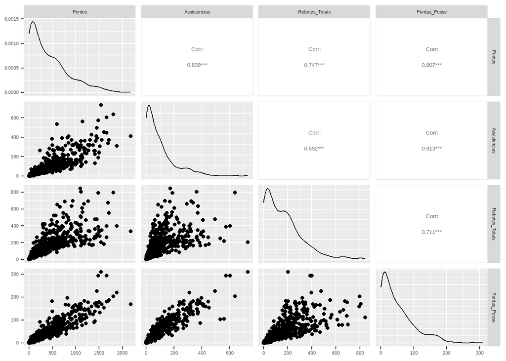

```r
ggpairs(jogadores_2024[, c("Pontos","Assistencias","Rebotes_Totais", "Perdas_Posse")])
```

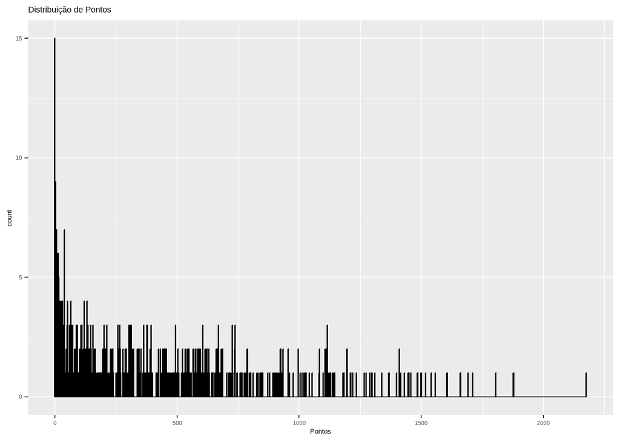

```r
ggplot(jogadores_2024, aes(x = Pontos)) +
  geom_histogram(binwidth = 2, fill = "blue", color = "black") +
  labs(title = "Distribuição de Pontos")
```

## QQPlot

Para checar se variável de “Pontos” segue uma distribuição normal

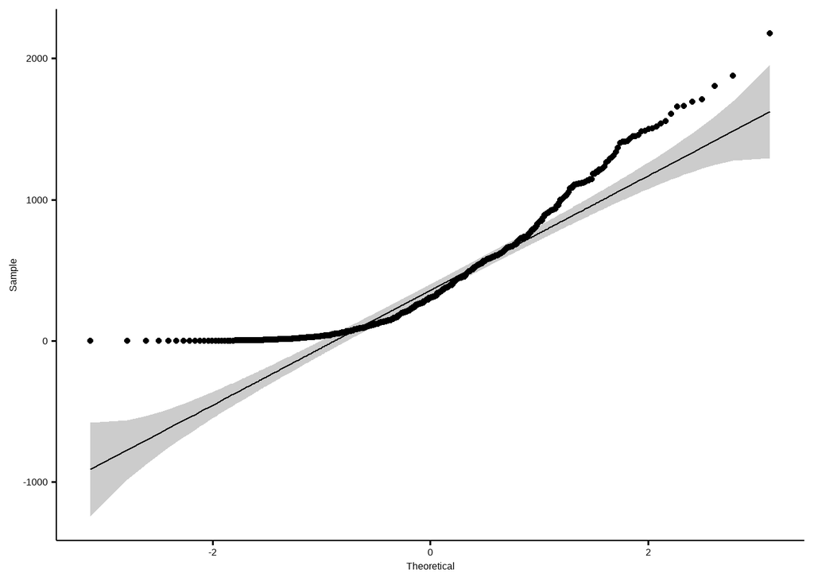

```r
ggqqplot(jogadores_2024$Pontos)
```

## Shapiro

Teste de normalidade de Shapiro-Wilk.

```r
shapiro.test(jogadores_2024$Pontos)
```

```
##
##  Shapiro-Wilk normality test
##
## data:  jogadores_2024$Pontos
## W = 0.87326, p-value < 2.2e-16
```

```r
diagnose(jogadores_2024)
```

| variables | types | missing_count | missing_percent | unique_count | unique_rate |
| --- | --- | --- | --- | --- | --- |
| ID | numeric | 0 | 0 | 407 | 0.73201439 |
| Jogador | character | 0 | 0 | 556 | 1.00000000 |
| Time | character | 0 | 0 | 30 | 0.05395683 |
| Idade | numeric | 0 | 0 | 22 | 0.03956835 |
| Jogos_Jogados | numeric | 0 | 0 | 71 | 0.12769784 |
| Vitorias | numeric | 0 | 0 | 53 | 0.09532374 |
| Derrotas | numeric | 0 | 0 | 51 | 0.09172662 |
| Minutos_Jogados | character | 0 | 0 | 545 | 0.98021583 |
| Pontos | numeric | 0 | 0 | 407 | 0.73201439 |
| Arremessos_Certos | numeric | 0 | 0 | 295 | 0.53057554 |

[output cut: 20 more lines]

## Imputação de dados faltantes

Aplica a técnica mice com o método PMM para preencher valores faltantes da base.

```r
imputacao <- mice(jogadores_2024, m= 1, method = "pmm", seed = 3010)
```

```
##
##   1   1
##   2   1
##   3   1
##   4   1
##   5   1
```

```r
jogadores_2024_imputado <- complete(imputacao)
```

## Histograma

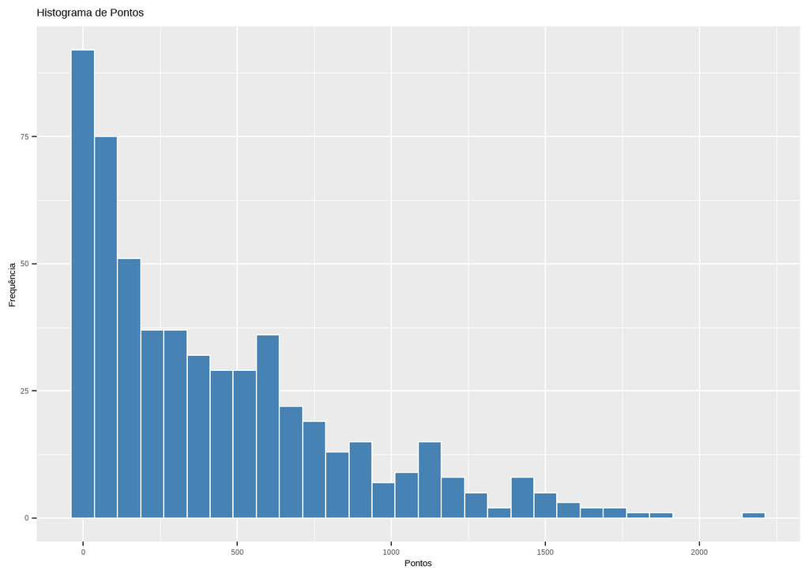

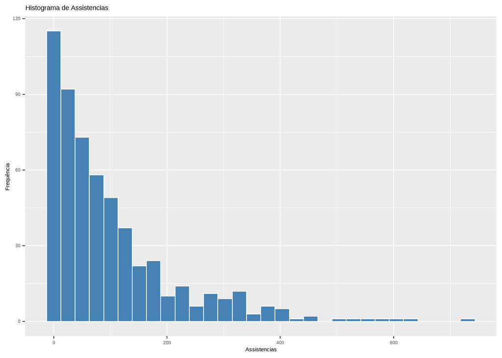

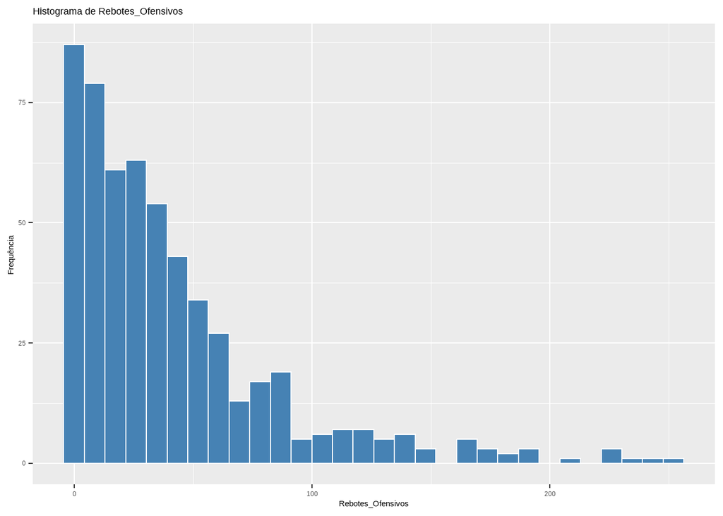

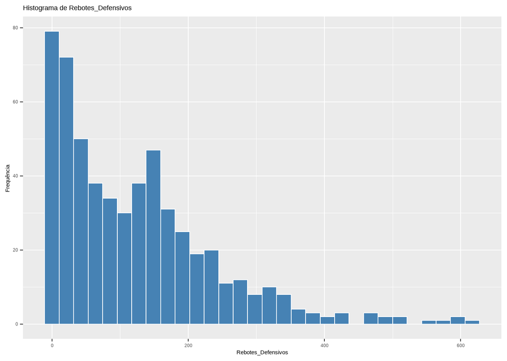

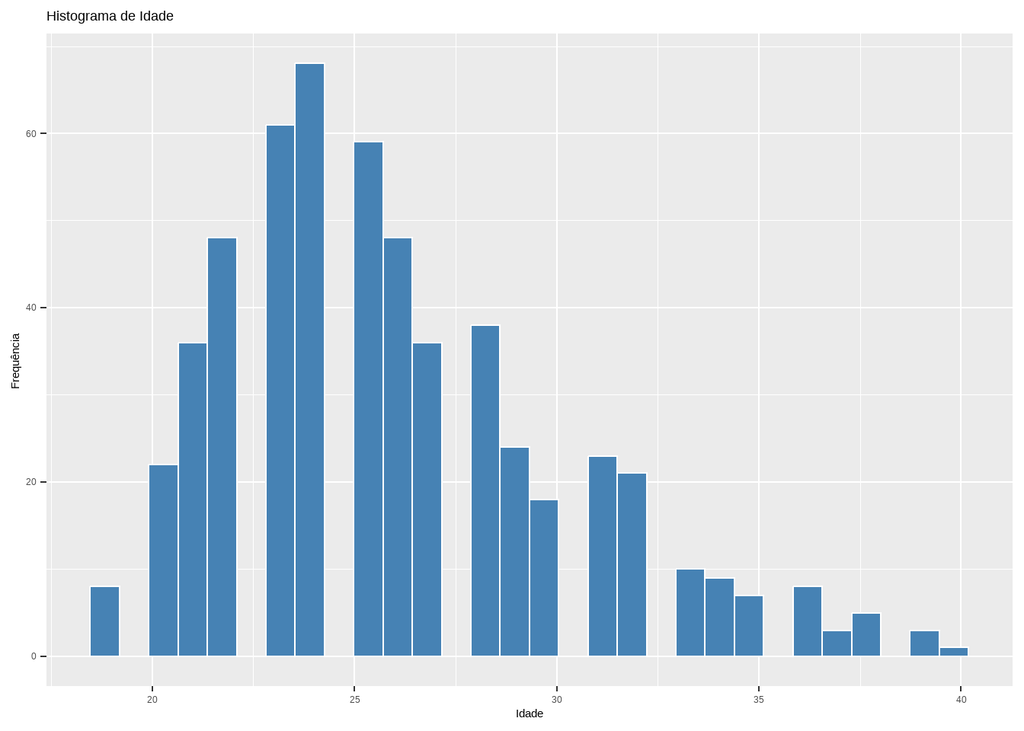

```r
colunas <- c("Pontos", "Assistencias", "Rebotes_Ofensivos", "Rebotes_Defensivos", "Idade")

for (n in colunas) {
  print(
    ggplot(jogadores_2024_imputado, aes_string(x=n))+
      geom_histogram(fill= "steelblue", color = "white", bins = 30) +
      labs(title = paste("Histograma de", n), x = n, y = "Frequência")
  )
}
```

## Teste de normalidade

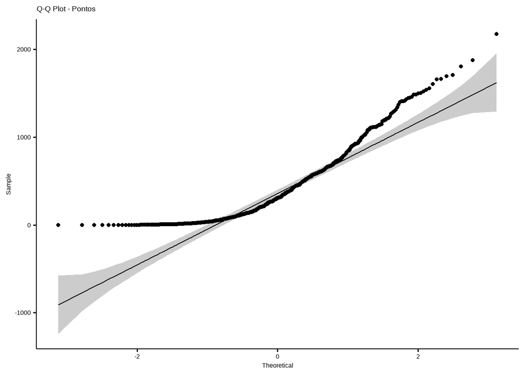

```r
ggqqplot(jogadores_2024_imputado$Pontos, title = "Q-Q Plot - Pontos")
```

```r
shapiro.test(jogadores_2024_imputado$Pontos)
```

```
##
##  Shapiro-Wilk normality test
##
## data:  jogadores_2024_imputado$Pontos
## W = 0.87326, p-value < 2.2e-16
```

```r
shapiro.test(jogadores_2024_imputado$Assistencias)
```

```
##
##  Shapiro-Wilk normality test
##
## data:  jogadores_2024_imputado$Assistencias
## W = 0.79226, p-value < 2.2e-16
```

## Outliers

```r
diagnose(jogadores_2024) %>%
  select(variables, missing_count, missing_percent)
```

| variables | missing_count | missing_percent |
| --- | --- | --- |
| ID | 0 | 0 |
| Jogador | 0 | 0 |
| Time | 0 | 0 |
| Idade | 0 | 0 |
| Jogos_Jogados | 0 | 0 |
| Vitorias | 0 | 0 |
| Derrotas | 0 | 0 |
| Minutos_Jogados | 0 | 0 |
| Pontos | 0 | 0 |
| Arremessos_Certos | 0 | 0 |

[output cut: 20 more lines]

```r
outliers <- diagnose_outlier(jogadores_2024_imputado)

head(outliers)
```

|  | variables | outliers_cnt | outliers_ratio | outliers_mean | with_mean | without_mean |
| --- | --- | --- | --- | --- | --- | --- |
| 1 | ID | 0 | 0.000000 | NaN | 278.00899 | 278.00899 |
| 2 | Idade | 20 | 3.597122 | 37.300 | 25.98201 | 25.55970 |
| 3 | Jogos_Jogados | 0 | 0.000000 | NaN | 39.94604 | 39.94604 |
| 4 | Vitorias | 0 | 0.000000 | NaN | 20.00000 | 20.00000 |
| 5 | Derrotas | 0 | 0.000000 | NaN | 19.94604 | 19.94604 |
| 6 | Pontos | 16 | 2.877698 | 1640.188 | 424.27698 | 388.25000 |

```r
outliers %>%
  filter(outliers_cnt > 0)
```

| variables | outliers_cnt | outliers_ratio | outliers_mean | with_mean | without_mean |
| --- | --- | --- | --- | --- | --- |
| Idade | 20 | 3.5971223 | 37.300000 | 25.9820144 | 25.559701 |
| Pontos | 16 | 2.8776978 | 1640.187500 | 424.2769784 | 388.250000 |
| Arremessos_Certos | 14 | 2.5179856 | 592.857143 | 155.2086331 | 143.904059 |
| Arremessos_Totais | 11 | 1.9784173 | 1253.363636 | 332.9478417 | 314.370642 |
| Tres_Pontos_Certos | 10 | 1.7985612 | 234.000000 | 50.2895683 | 46.924908 |
| Tres_Pontos_Tentados | 9 | 1.6187050 | 619.888889 | 140.0359712 | 132.140768 |
| Lances_Livres_Certos | 43 | 7.7338129 | 270.488372 | 63.5701439 | 46.226121 |
| Lances_Livres_Tentados | 35 | 6.2949640 | 349.542857 | 81.3723022 | 63.357006 |
| Rebotes_Ofensivos | 39 | 7.0143885 | 165.384615 | 41.5449640 | 32.203095 |
| Rebotes_Defensivos | 17 | 3.0575540 | 495.764706 | 123.1546763 | 111.402597 |

[output cut: 9 more lines]

```r
head(jogadores_2024)
```

| ID | Jogador | Time | Idade | Jogos_Jogados | Vitorias | Derrotas | Minutos_Jogados | Pontos | Arremessos_Certos | Arremessos_Totais | Porcentagem_Acerto_Arremesso | Tres_Pontos_Certos | Tres_Pontos_Tentados | Porcentagem_Acerto_Tres | Lances_Livres_Certos | Lances_Livres_Tentados | Porcentagem_Acerto_Lance_Livre | Rebotes_Ofensivos | Rebotes_Defensivos | Rebotes_Totais | Assistencias | Perdas_Posse | Roubos | Bloqueios | Faltas | Pontos_Fantasia | Duplos_Duplos | Triplos_Duplos | PlusMinus |
| --- | --- | --- | --- | --- | --- | --- | --- | --- | --- | --- | --- | --- | --- | --- | --- | --- | --- | --- | --- | --- | --- | --- | --- | --- | --- | --- | --- | --- | --- |
| 1 | Shai Gilgeous-Alexander | OKC | 26 | 66 | 55 | 11 | 2268.4 | 2176 | 750 | 1427 | 52.6 | 142 | 383 | 37.1 | 534 | 593 | 90.1 | 60 | 273 | 333 | 412 | 168 | 117 | 69 | 147 | 3584 | 5 | 0 | 791 |
| 2 | Anthony Edwards | MIN | 23 | 68 | 39 | 29 | 2479.2 | 1878 | 615 | 1393 | 44.1 | 275 | 688 | 40.0 | 373 | 444 | 84.0 | 51 | 345 | 396 | 311 | 219 | 77 | 42 | 124 | 2958 | 6 | 0 | 212 |
| 3 | Nikola Jokić | DEN | 30 | 62 | 41 | 21 | 2262.9 | 1806 | 690 | 1201 | 57.5 | 117 | 283 | 41.3 | 309 | 383 | 80.7 | 179 | 617 | 796 | 637 | 203 | 109 | 43 | 143 | 3970 | 52 | 29 | 499 |
| 4 | Jayson Tatum | BOS | 27 | 63 | 45 | 18 | 2306.8 | 1710 | 582 | 1281 | 45.4 | 227 | 644 | 35.2 | 319 | 393 | 81.2 | 42 | 509 | 551 | 370 | 186 | 69 | 32 | 141 | 3043 | 29 | 2 | 443 |
| 5 | Giannis Antetokounmpo | MIL | 30 | 56 | 32 | 24 | 1903.6 | 1693 | 670 | 1118 | 59.9 | 8 | 45 | 17.8 | 345 | 575 | 60.0 | 129 | 545 | 674 | 338 | 182 | 46 | 70 | 138 | 3175 | 47 | 7 | 232 |
| 6 | Cade Cunningham | DET | 23 | 65 | 37 | 28 | 2282.4 | 1663 | 616 | 1337 | 46.1 | 139 | 393 | 35.4 | 292 | 339 | 86.1 | 52 | 346 | 398 | 603 | 293 | 67 | 49 | 179 | 3100 | 30 | 9 | 183 |

## Matriz de correlação

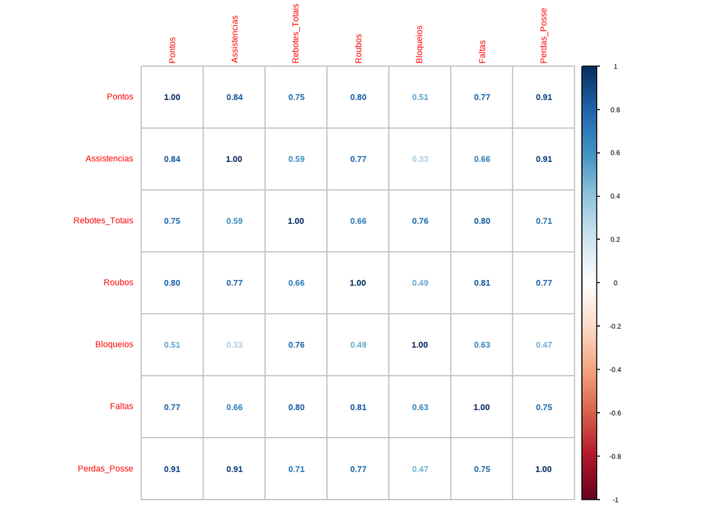

```r
correlacao <- jogadores_2024_imputado %>%
  select(Pontos, Assistencias, Rebotes_Totais, Roubos, Bloqueios, Faltas, Perdas_Posse)

cor_matrix <- cor(correlacao, use = "complete.obs")
corrplot(cor_matrix, method = "number" )
```

## Inferência

```r
anova_times <- aov(Pontos ~ Time, data = jogadores_2024_imputado)
summary(anova_times)
```

```
##              Df   Sum Sq Mean Sq F value Pr(>F)
## Time         29  1353096   46658    0.26      1
## Residuals   526 94543041  179740
```

[figure not shown]

https://fixturedownload.com/results/nba-2024

[figure not shown]

https://www.espn.com.br/nba/estatisticas/jogador/_/stat/gols